# WGCNA in Proteomic data. All with 0

# 1 Data input, cleaning and pre-processing

Load protein abundance data, pre-process them into a format suitable for network analysis, and clean the data by removing obvious outlier samples as well as proteins and samples with excessive numbers of missing entries.

## 1.a Loading expression data

The expression data is contained in the files:

- 1-9_A1_A2_A3__precol2cm_col75cm_top15_70000_3e6_50_35000_5e4_100_iw4_excl40_2h_200nlmin_1ul_A1vsA2vsA3.xlsx that comes with this tutorial.
- 10-14_C1_C2_C3__precol2cm_col75cm_top15_70000_3e6_50_35000_5e4_100_iw4_excl40_2h_200nlmin_1ul_C1vsC2vsC3.xlsx

These files contains several quality parametres. We have used grouped protein abundance to compare samples.

Files not share same proteins, this is one important point to discuss. One aporximation is consider missing protein with 0 abundance. Also it can be considered only the shared proetins.

```r
library(readxl)

# Load the WGCNA package
library(WGCNA);
# The following setting is important, do not omit.
options(stringsAsFactors = FALSE)
#Read in the female liver data set
pheno<-read_excel("./nomenclatura.xlsx")
# Take a quick look at what is in the data set:
dim(pheno)
```

```
## [1] 6 3
```

```r
names(pheno)
```

```
## [1] "Nomenclatura Raw Data"         "Nomenclatura mostres de miRNA"
## [3] "Nomenclatura unificada"
```

```r
load("RESULTATS/OBJECTES/data_abundance_0")
datExpr0 = as.data.frame(data_abundance_0)
rownames(datExpr0) = datExpr0$Row.names
datExpr0<-datExpr0[,-1]
datExpr0<-t(datExpr0)
```

## 1.b Checking data for excessive missing values and identification of outlier microarray samples

We first check for proteins and samples with too many missing values:

```r
gsg = goodSamplesGenes(datExpr0, verbose = 3);
```

```
##  Flagging genes and samples with too many missing values...
##   ..step 1
##   ..Excluding 16 genes from the calculation due to too many missing samples or zero variance.
##   ..step 2
```

```r
gsg$allOK
```

```
## [1] FALSE
```

```r
if (!gsg$allOK)
{
# Optionally, print the gene and sample names that were removed:
if (sum(!gsg$goodGenes)>0)
printFlush(paste("Removing genes:", paste(names(datExpr0)[!gsg$goodGenes], collapse = ", ")));
if (sum(!gsg$goodSamples)>0)
printFlush(paste("Removing samples:", paste(rownames(datExpr0)[!gsg$goodSamples], collapse = ", ")));
# Remove the offending genes and samples from the data:
datExpr0 = datExpr0[gsg$goodSamples, gsg$goodGenes]
}
```

```
## Removing genes:
```

Next we cluster the samples (in contrast to clustering proteins that will come later) to see if there are any obvious outliers.

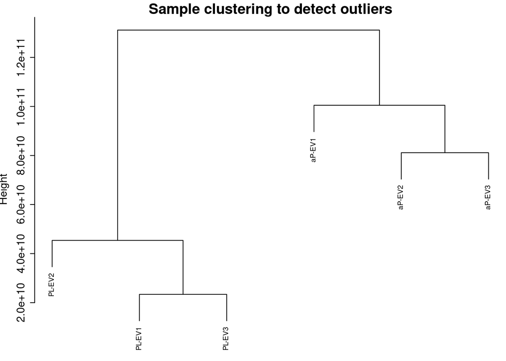

```r
sampleTree = hclust(dist(datExpr0), method = "average");
# Plot the sample tree: Open a graphic output window of size 12 by 9 inches
# The user should change the dimensions if the window is too large or too small.
# sizeGrWindow(12,9)
#pdf(file = "Plots/sampleClustering.pdf", width = 12, height = 9);
par(cex = 0.6);
par(mar = c(0,4,2,0))
plot(sampleTree, main = "Sample clustering to detect outliers", sub="", xlab="", cex.lab = 1.5,
cex.axis = 1.5, cex.main = 2)
```

## 1.c Loading clinical trait data

```r
pheno<-read_excel("./nomenclatura.xlsx")
dim(pheno)
```

```
## [1] 6 3
```

```r
names(pheno)
```

```
## [1] "Nomenclatura Raw Data"         "Nomenclatura mostres de miRNA"
## [3] "Nomenclatura unificada"
```

```r
pheno$grup<-as.factor(c("NaCl","NaCl","NaCl","PR","PR","PR"))
# remove columns that hold information we do not need.
allTraits = data.frame(pheno)

dim(allTraits)
```

```
## [1] 6 4
```

```r
names(allTraits)
```

```
## [1] "Nomenclatura.Raw.Data"         "Nomenclatura.mostres.de.miRNA"
## [3] "Nomenclatura.unificada"        "grup"
```

```r
# Form a data frame analogous to expression data that will hold the clinical traits.
nameSamples = rownames(datExpr0);
traitRows = match(nameSamples, allTraits$Nomenclatura.unificada);
datTraits = allTraits[traitRows,];
rownames(datTraits) = allTraits[traitRows, 1];
collectGarbage()
```

We now have the expression data in the variable datExpr, and the corresponding clinical traits in the variable datTraits.

## Sample dendrogram

Before we continue with network construction and module detection, we visualize how the clinical traits relate to the sample dendrogram

```r
# Re-cluster samples
sampleTree2 = hclust(dist(datExpr0), method = "average")
# Convert traits to a color representation: white means low, red means high, grey means missing entry
datTraits
```

```
##    Nomenclatura.Raw.Data Nomenclatura.mostres.de.miRNA Nomenclatura.unificada
## C1                    C1                          PRP1                 aP-EV1
## C2                    C2                          PRP2                 aP-EV2
## C3                    C3                          PRP3                 aP-EV3
## A1                    A1                         NaCl1                 PL-EV1
## A2                    A2                         NaCl2                 PL-EV2
## A3                    A3                         NaCL3                 PL-EV3
##    grup
## C1   PR
## C2   PR
## C3   PR
## A1 NaCl
## A2 NaCl
## A3 NaCl
```

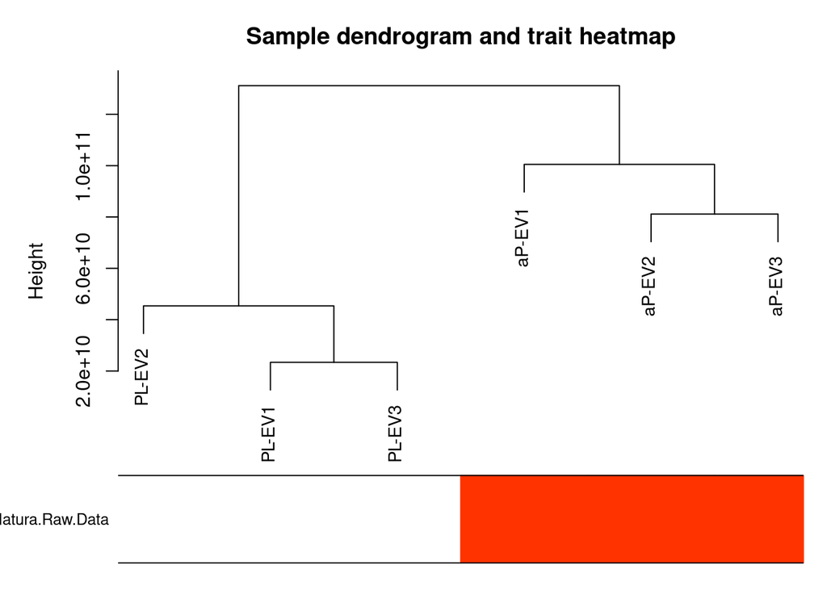

```r
traitColors = numbers2colors(as.numeric(datTraits$grup), signed = FALSE);
# Plot the sample dendrogram and the colors underneath.
plotDendroAndColors(sampleTree2, traitColors,
groupLabels = names(datTraits),
main = "Sample dendrogram and trait heatmap")
```

# 2.1 Automatic network construction and module detection

## 2.a.1 Choosing the soft-thresholding power: analysis of network topology

Constructing a weighted gene network entails the choice of the soft thresholding power β to which co-expression similarity is raised to calculate adjacency [1]. The authors of [1] have proposed to choose the soft thresholding power based on the criterion of approximate scale-free topology. We refer the reader to that work for more details; here we illustrate the use of the function pickSoftThreshold that performs the analysis of network topology and aids the user in choosing a proper soft-thresholding power.

```r
# Choose a set of soft-thresholding powers
powers = c(c(1:50), seq(from = 52, to=100, by=2))
# Call the network topology analysis function
sft = pickSoftThreshold(datExpr0,
                         networkType = "signed hybrid",
                        powerVector = powers, verbose = 5)
```

```
## pickSoftThreshold: will use block size 1154.
##  pickSoftThreshold: calculating connectivity for given powers...
##    ..working on genes 1 through 1154 of 1154
```

```
##    Power SFT.R.sq    slope truncated.R.sq mean.k. median.k. max.k.
## 1      1  0.23800  0.68200          0.413   457.0     531.0  692.0
## 2      2  0.26100  0.34500          0.418   341.0     385.0  564.0
## 3      3  0.21800  0.21000          0.453   276.0     305.0  479.0
## 4      4  0.18000  0.14000          0.442   233.0     252.0  418.0
## 5      5  0.11300  0.08340          0.523   202.0     216.0  375.0
## 6      6  0.02310  0.03280          0.420   179.0     189.0  343.0
## 7      7  0.00076 -0.00541          0.388   161.0     168.0  316.0
## 8      8  0.03720 -0.03970          0.257   147.0     152.0  293.0
## 9      9  0.11900 -0.07110          0.215   135.0     141.0  275.0
## 10    10  0.22500 -0.09300          0.195   125.0     129.0  259.0
## 11    11  0.38100 -0.11400          0.297   116.0     119.0  245.0
## 12    12  0.42900 -0.13100          0.323   108.0     111.0  232.0
## 13    13  0.46800 -0.15600          0.352   102.0     104.0  221.0
## 14    14  0.48600 -0.17300          0.359    96.2      98.1  211.0
```

[output cut: 61 more lines]

```r
# Plot the results:
sizeGrWindow(9, 5)
par(mfrow = c(1,2));
cex1 = 0.9;
# Scale-free topology fit index as a function of the soft-thresholding power
```

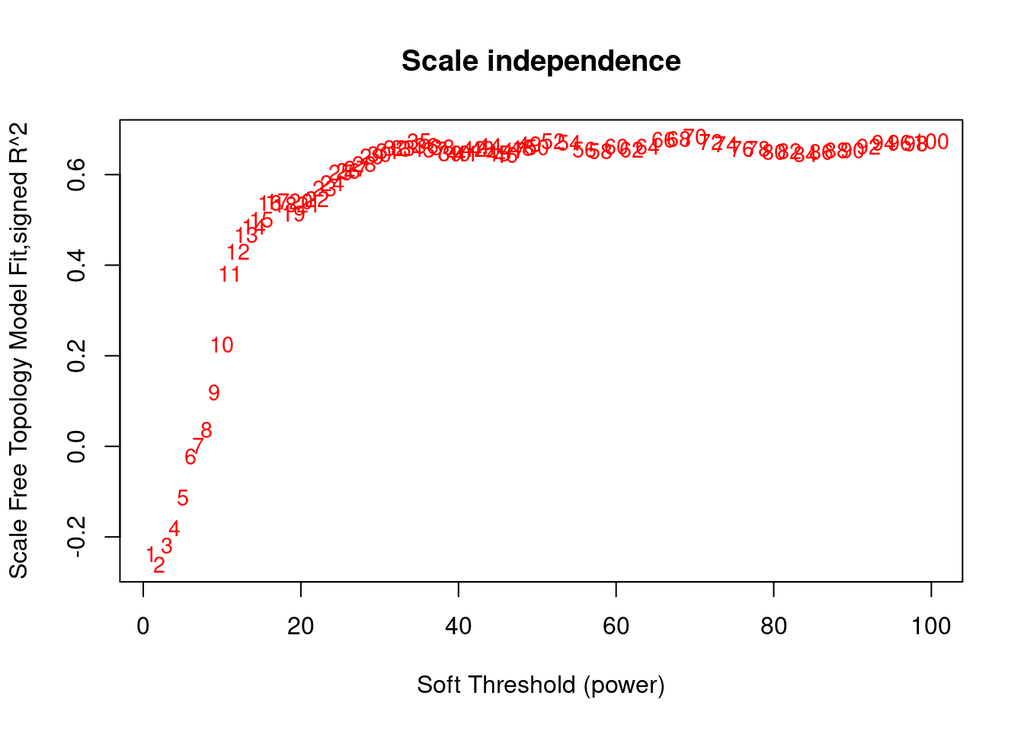

```r
plot(sft$fitIndices[,1], -sign(sft$fitIndices[,3])*sft$fitIndices[,2],
xlab="Soft Threshold (power)",ylab="Scale Free Topology Model Fit,signed R^2",type="n",
main = paste("Scale independence"));
text(sft$fitIndices[,1], -sign(sft$fitIndices[,3])*sft$fitIndices[,2],
labels=powers,cex=cex1,col="red");
# this line corresponds to using an R^2 cut-off of h
abline(h=0.90,col="red")
```

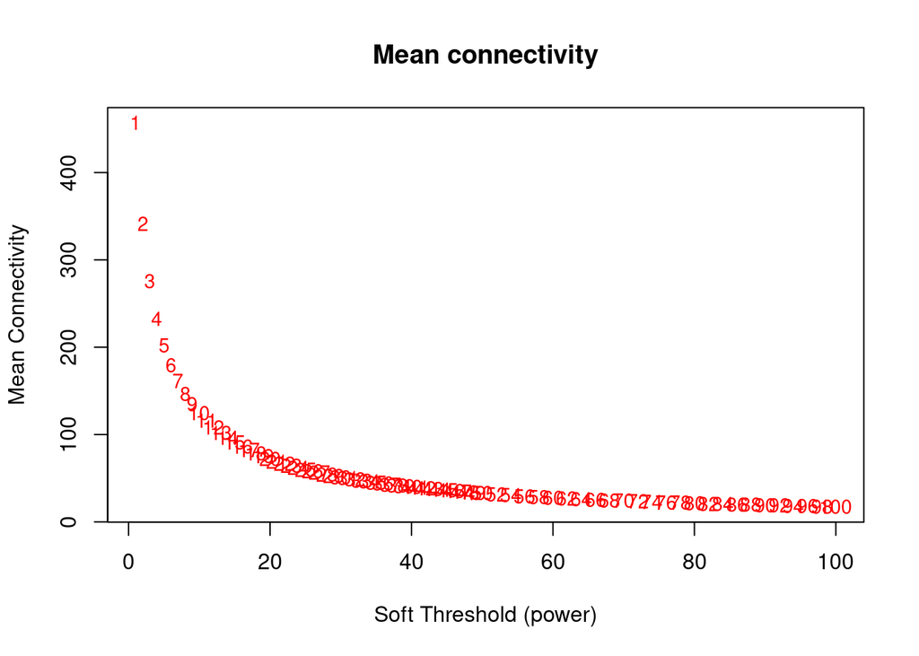

```r
# Mean connectivity as a function of the soft-thresholding power
plot(sft$fitIndices[,1], sft$fitIndices[,5],
xlab="Soft Threshold (power)",ylab="Mean Connectivity", type="n",
main = paste("Mean connectivity"))
text(sft$fitIndices[,1], sft$fitIndices[,5], labels=powers, cex=cex1,col="red")
```

# Batch effect?

Groups are very different (between other things, are not share proteins).

We normalize the data with combat in other report

## 2.a.2 One-step network construction and module detection

Constructing the gene network and identifying modules is now a simple function call:

```r
pw<-15
net = blockwiseModules(datExpr0, power = pw,
TOMType = "unsigned", minModuleSize = 30,
reassignThreshold = 0, mergeCutHeight = 0.25,
numericLabels = TRUE, pamRespectsDendro = FALSE,
saveTOMs = TRUE,
saveTOMFileBase = "femaleMouseTOM",
verbose = 3)
```

```
##  Calculating module eigengenes block-wise from all genes
##    Flagging genes and samples with too many missing values...
##     ..step 1
##  ..Working on block 1 .
##     TOM calculation: adjacency..
##     ..will not use multithreading.
##      Fraction of slow calculations: 0.000000
##     ..connectivity..
##     ..matrix multiplication (system BLAS)..
##     ..normalization..
##     ..done.
##    ..saving TOM for block 1 into file femaleMouseTOM-block.1.RData
##  ....clustering..
##  ....detecting modules..
##  ....calculating module eigengenes..
##  ....checking kME in modules..
##  ..merging modules that are too close..
##      mergeCloseModules: Merging modules whose distance is less than 0.25
##        Calculating new MEs...
```

We have chosen the soft thresholding power 15 , a relatively large minimum module size of 30, and a medium sensitivity (deepSplit=2) to cluster splitting. The parameter mergeCutHeight is the threshold for merging of modules. We have also instructed the function to return numeric, rather than color, labels for modules, and to save the Topological Overlap Matrix. The output of the function may seem somewhat cryptic, but it is easy to use. For example, net$colors contains the module assignment, and net$MEs contains the module eigengenes of the modules.

```r
 table(net$colors)
```

```
##
##   1   2   3   4   5   6
## 516 248 131 126  89  44
```

The dendrogram can be displayed together with the color assignment using the following code:

```r
# open a graphics window
sizeGrWindow(12, 9)
# Convert labels to colors for plotting
mergedColors = labels2colors(net$colors)
# Plot the dendrogram and the module colors underneath
```

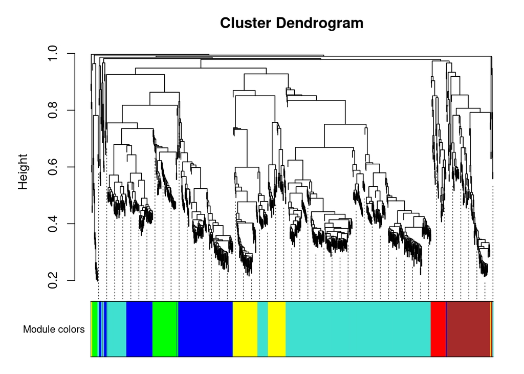

```r
plotDendroAndColors(net$dendrograms[[1]], mergedColors[net$blockGenes[[1]]],
"Module colors",
dendroLabels = FALSE, hang = 0.03,
addGuide = TRUE, guideHang = 0.05)
```

We note that if the user would like to change some of the tree cut, module membership, and module merging criteria, the package provides the function recutBlockwiseTrees that can apply modified criteria without having to recompute the network and the clustering dendrogram. This may save a sub-stantial amount of time. We now save the module assignment and module eigengene information necessary for subsequent analysis.

```r
moduleLabels = net$colors
moduleColors = labels2colors(net$colors)
MEs = net$MEs;
geneTree = net$dendrograms[[1]];
save(MEs, moduleLabels, moduleColors, geneTree,
file = "FemaleLiver-02-networkConstruction-auto.RData")
```

# 3 Relating modules to external clinical trait

## 3a Quantifying module–trait associations

In this analysis we would like to identify modules that are significantly associated with the measured clinical traits. Since we already have a summary profile (eigengene) for each module, we simply correlate eigengenes with external traits and look for the most significant associations

```r
# Define numbers of genes and samples
nGenes = ncol(datExpr0)
nSamples = nrow(datExpr0)
# Recalculate MEs with color labels
MEs0 = moduleEigengenes(datExpr0, moduleColors)$eigengenes
MEs = orderMEs(MEs0)
moduleTraitCor = cor(MEs, as.numeric(datTraits$grup), use = "p")
moduleTraitPvalue = corPvalueStudent(moduleTraitCor, nSamples)
```

Since we have a moderately large number of modules and traits, a suitable graphical representation will help in reading the table. We color code each association by the correlation value:

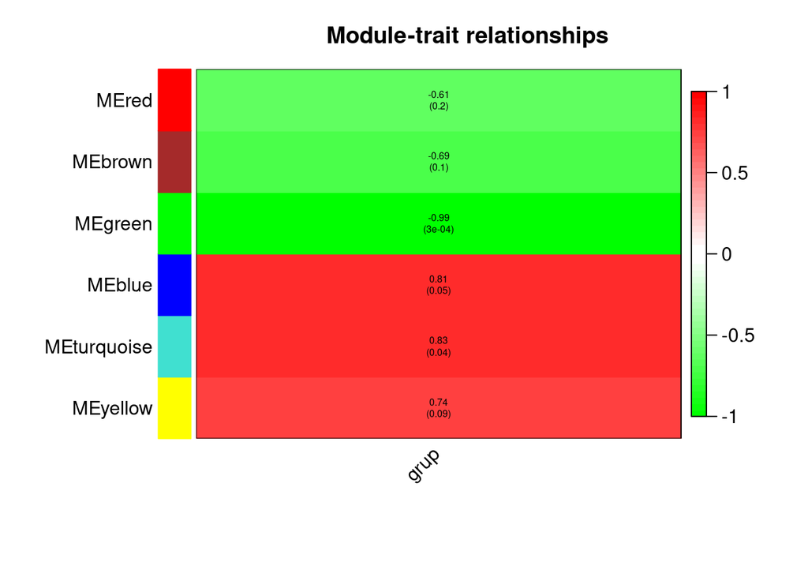

```r
# Will display correlations and their p-values
textMatrix = paste(signif(moduleTraitCor, 2), "\n(",
signif(moduleTraitPvalue, 1), ")", sep = "");
dim(textMatrix) = dim(moduleTraitCor)
par(mar = c(6, 8.5, 3, 3));
# Display the correlation values within a heatmap plot
labeledHeatmap(Matrix = moduleTraitCor,
xLabels = names(datTraits)[4],
yLabels = names(MEs),
ySymbols = names(MEs),
colorLabels = FALSE,
colors = greenWhiteRed(50),
textMatrix = textMatrix,
setStdMargins = FALSE,
cex.text = 0.5,
zlim = c(-1,1),
main = paste("Module-trait relationships"))
```

The analysis identifies the 2 significant module–trait associations. We will concentrate on **GRUP** as the trait of interest.

## 3.b Gene relationship to trait and important modules: Gene Significance and Module Membership

We quantify associations of individual genes with our trait of interest by defining Gene Significance GS as (the absolute value of) the correlation between the gene and the trait. For each module, we also define a quantitative measure of module membership MM as the correlation of the module eigengene and the gene expression profile. This allows us to quantify the similarity of all proteins on the array to every module

```r
# Define variable weight containing the weight column of datTrait
grup = as.data.frame(as.numeric(datTraits$grup));
names(grup) = "grup"
# names (colors) of the modules
modNames = substring(names(MEs), 3)
geneModuleMembership = as.data.frame(cor(datExpr0, MEs, use = "p"));
MMPvalue = as.data.frame(corPvalueStudent(as.matrix(geneModuleMembership), nSamples));


names(geneModuleMembership) = paste("MM", modNames, sep="")
names(MMPvalue) = paste("p.MM", modNames, sep="")
geneTraitSignificance = as.data.frame(cor(datExpr0, grup, use = "p"))
GSPvalue = as.data.frame(corPvalueStudent(as.matrix(geneTraitSignificance), nSamples))
names(geneTraitSignificance) = paste("GS.", names(grup), sep="")
names(GSPvalue) = paste("p.GS.", names(grup), sep="")
```

##3.c Intramodular analysis: identifying genes with high GS and MM

```r
moduls_int<-gsub("ME","",rownames(moduleTraitPvalue)[moduleTraitPvalue<=0.05])
module = moduls_int[1]
column = match(module, modNames);
moduleGenes = moduleColors==module;
sizeGrWindow(7, 7)
par(mfrow = c(1,1))
```

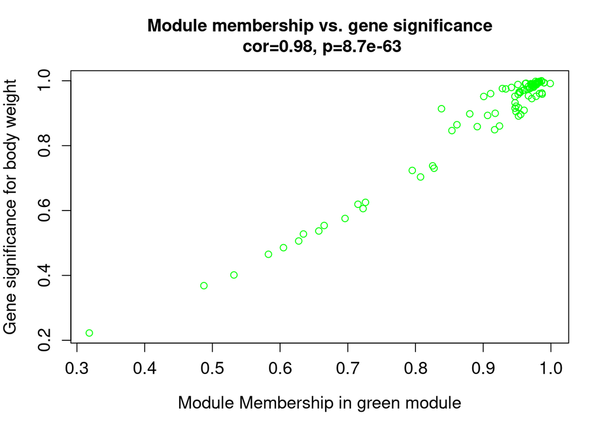

```r
verboseScatterplot(abs(geneModuleMembership[moduleGenes, column]),
                   abs(geneTraitSignificance[moduleGenes, 1]),
xlab = paste("Module Membership in", module, "module"),
ylab = "Gene significance for body weight",
main = paste("Module membership vs. gene significance\n"),
cex.main = 1.2, cex.lab = 1.2, cex.axis = 1.2, col = module)
```

```r
module = moduls_int[2]
column = match(module, modNames);
moduleGenes = moduleColors==module;
sizeGrWindow(7, 7)
par(mfrow = c(1,1))
```

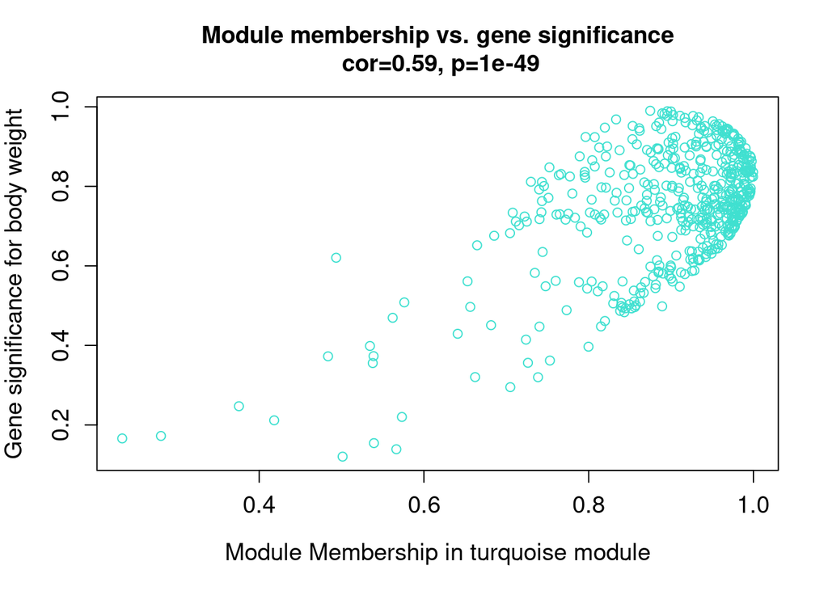

```r
verboseScatterplot(abs(geneModuleMembership[moduleGenes, column]),
                   abs(geneTraitSignificance[moduleGenes, 1]),
xlab = paste("Module Membership in", module, "module"),
ylab = "Gene significance for body weight",
main = paste("Module membership vs. gene significance\n"),
cex.main = 1.2, cex.lab = 1.2, cex.axis = 1.2, col = module)
```

GS and MM are correlated, illustrating that proteins highly significantly associated with a trait are often also the most important (central) elements of modules associated with the trait. The reader is encouraged to try this code with other significance trait/module correlation.

## 3.d Summary output of network analysis results

We have found modules with high association with our trait of interest, and have identified their central players by the Module Membership measure. We now merge this statistical information with protein annotation.

```r
# colnames(datExpr0)
# colnames(datExpr0)[moduleColors=="green"]
```

```r
library(clusterProfiler)

library(dplyr)
library(DT)
```

```r
gene<-colnames(datExpr0)[moduleColors==moduls_int[1]]
gene<-unlist(strsplit(gene,"\r\n"))
kegg_green<-
enrichKEGG(
gene,
organism = "hsa",
keyType = "uniprot",
pvalueCutoff = 0.05,

pAdjustMethod = "BH",
qvalueCutoff = 0.2,
use_internal_data = FALSE
)
```

```
## Reading KEGG annotation online: "https://rest.kegg.jp/link/hsa/pathway"...
```

```
## Reading KEGG annotation online: "https://rest.kegg.jp/list/pathway/hsa"...
```

```
## Reading KEGG annotation online: "https://rest.kegg.jp/conv/uniprot/hsa"...
```

```r
gene<-colnames(datExpr0)[moduleColors==moduls_int[2]]
gene<-unlist(strsplit(gene,"\r\n"))
kegg_blue<-
enrichKEGG(
gene,
organism = "hsa",
keyType = "uniprot",
pvalueCutoff = 0.05,

pAdjustMethod = "BH",
qvalueCutoff = 0.2,
use_internal_data = FALSE
)
```

```r
datatable(kegg_green@result)
```

|  | category | subcategory | ID | Description | GeneRatio | BgRatio | pvalue | p.adjust | qvalue | geneID | Count |
| --- | --- | --- | --- | --- | --- | --- | --- | --- | --- | --- | --- |
| hsa04610 | Organismal Systems | Immune system | hsa04610 | Complement and coagulation cascades | 11/55 | 110/10895 | 5.513790767926066e-12 | 1.064161618209731e-09 | 9.112264742783077e-10 | P00747/P01008/P01009/P01031/P02671/P02745/P02746/P04004/P07357/P08603/P08697 | 11 |
| hsa04510 | Cellular Processes | Cellular community - eukaryotes | hsa04510 | Focal adhesion | 7/55 | 306/10895 | 0.0008216390914441722 | 0.06131113107953788 | 0.05249985044716362 | O60610/P04004/P05771/P08648/P18206/P22105/P49747 | 7 |
| hsa05146 | Human Diseases | Infectious disease: parasitic | hsa05146 | Amoebiasis | 5/55 | 151/10895 | 0.0009530227628943712 | 0.06131113107953788 | 0.05249985044716362 | P05771/P07357/P18206/P61020/Q00722 | 5 |
| hsa05150 | Human Diseases | Infectious disease: bacterial | hsa05150 | Staphylococcus aureus infection | 5/55 | 162/10895 | 0.001304917981300575 | 0.06296229259775275 | 0.05391371659583956 | P00747/P01031/P02745/P02746/P08603 | 5 |
| hsa05204 | Human Diseases | Cancer: overview | hsa05204 | Chemical carcinogenesis - DNA adducts | 4/55 | 101/10895 | 0.001651502432484325 | 0.06374799389389496 | 0.05458650145263981 | P0DMN0/P0DMM9/P50225/P78417 | 4 |
| hsa05133 | Human Diseases | Infectious disease: bacterial | hsa05133 | Pertussis | 4/55 | 111/10895 | 0.002334051570649639 | 0.07507865885589672 | 0.0642887888757883 | P01031/P02745/P02746/P08648 | 4 |
| hsa04512 | Environmental Information Processing | Signaling molecules and interaction | hsa04512 | ECM-receptor interaction | 4/55 | 129/10895 | 0.004013156328404042 | 0.1084589485929021 | 0.09287185671712918 | P04004/P08648/P22105/P49747 | 4 |
| hsa05020 | Human Diseases | Neurodegenerative disease | hsa05020 | Prion disease | 7/55 | 413/10895 | 0.004507491315593415 | 0.1084589485929021 | 0.09287185671712918 | P01031/P02745/P02746/P07357/P25705/Q07812/Q99436 | 7 |
| hsa05171 | Human Diseases | Infectious disease: viral | hsa05171 | Coronavirus disease - COVID-19 | 6/55 | 317/10895 | 0.005057671177907353 | 0.1084589485929021 | 0.09287185671712918 | P01031/P02671/P02745/P02746/P05771/P07357 | 6 |
| hsa04810 | Cellular Processes | Cell motility | hsa04810 | Regulation of actin cytoskeleton | 6/55 | 343/10895 | 0.007370703642561604 | 0.1343462310915043 | 0.1150387689193683 | O60610/P01031/P07357/P08648/P18206/Q8WUW1 | 6 |

[output cut: 183 more lines]

```r
datatable(kegg_blue@result)
```

|  | category | subcategory | ID | Description | GeneRatio | BgRatio | pvalue | p.adjust | qvalue | geneID | Count |
| --- | --- | --- | --- | --- | --- | --- | --- | --- | --- | --- | --- |
| hsa04144 | Cellular Processes | Transport and catabolism | hsa04144 | Endocytosis | 41/321 | 335/10895 | 5.190434425662949e-15 | 1.370274688375019e-12 | 1.076332191426948e-12 | O14964/O15143/O15511/O43633/O60493/P01889/P02786/P09496/P0DM…… | 41 |
| hsa04611 | Organismal Systems | Immune system | hsa04611 | Platelet activation | 27/321 | 173/10895 | 9.419626018738133e-13 | 1.243390634473433e-10 | 9.766664872060064e-11 | O00161/O43306/P02452/P02461/P04275/P04899/P07948/P08123/P08754/P12318/P12931/P17301/P23219/P24557/P30273/P36873/P51575/P61586/P62136/P62140/P62834/P63261/Q13094/Q14344/Q86UX7/Q96RI0/Q9BV40 | 27 |
| hsa05100 | Human Diseases | Infectious disease: bacterial | hsa05100 | Bacterial invasion of epithelial cells | 18/321 | 120/10895 | 1.239755216449552e-08 | 1.090984590475606e-06 | 8.569536057563574e-07 | O15143/O15511/P09496/P12931/P50570/P59998/P61158/P61160/P61586/P63000/P63261/P84095/Q00610/Q05193/Q13418/Q14247/Q9NVA2/Q9Y6W5 | 18 |
| hsa04810 | Cellular Processes | Cell motility | hsa04810 | Regulation of actin cytoskeleton | 31/321 | 343/10895 | 2.544324676564663e-08 | 1.440057498580166e-06 | 1.131145642824134e-06 | O15143/O15511/P01111/P05107/P10301/P11215/P12931/P13612/P151…… | 31 |
| hsa04145 | Cellular Processes | Transport and catabolism | hsa04145 | Phagosome | 26/321 | 253/10895 | 2.727381626098799e-08 | 1.440057498580166e-06 | 1.131145642824134e-06 | O14964/O15400/O75015/P01889/P02786/P04839/P05107/P11215/P11279/P12318/P13473/P13498/P17301/P20339/P20645/P27824/P31146/P38606/P51148/P51149/P61421/P63000/P63261/Q15836/Q86Y82/Q93050 | 26 |
| hsa05132 | Human Diseases | Infectious disease: bacterial | hsa05132 | Salmonella infection | 30/321 | 342/10895 | 8.449012713224927e-08 | 3.717565593818968e-06 | 2.920097376325107e-06 | O00592/O15143/O15511/O75369/P07355/P08575/P10301/P10599/P112…… | 30 |
| hsa04670 | Organismal Systems | Immune system | hsa04670 | Leukocyte transendothelial migration | 20/321 | 172/10895 | 1.550212510994416e-07 | 5.846515755750369e-06 | 4.59235886715639e-06 | O00501/O15551/P04839/P04899/P05107/P08754/P11215/P13498/P13612/P14209/P15153/P15311/P20701/P26038/P61586/P62834/P63000/P63261/Q96AP7/Q9Y624 | 20 |
| hsa04510 | Cellular Processes | Cellular community - eukaryotes | hsa04510 | Focal adhesion | 27/321 | 306/10895 | 3.4372446924781e-07 | 1.134290748517773e-05 | 8.909700058134023e-06 | O75369/P02452/P02458/P02462/P04275/P08123/P08572/P12109/P12111/P12931/P13612/P15153/P17301/P24821/P36873/P61586/P62136/P62140/P62834/P62993/P63000/P63261/P78509/Q13418/Q14315/Q15942/Q9HBI1 | 27 |
| hsa05135 | Human Diseases | Infectious disease: bacterial | hsa05135 | Yersinia infection | 20/321 | 202/10895 | 2.064699362927879e-06 | 6.056451464588444e-05 | 4.757260520430317e-05 | O15117/O15143/O15511/O43561/O75563/P06239/P12318/P12931/P13612/P15153/P42768/P59998/P61158/P61160/P61586/P63000/P63261/P84095/Q13094/Q9Y6W5 | 20 |
| hsa04666 | Organismal Systems | Immune system | hsa04666 | Fc gamma R-mediated phagocytosis | 16/321 | 137/10895 | 2.606077359320116e-06 | 6.487687125538866e-05 | 5.095990286009396e-05 | O15143/O15511/O43561/O75015/P07948/P08575/P12318/P15153/P42768/P50570/P59998/P61158/P61160/P63000/Q05655/Q9Y6W5 | 16 |

[output cut: 254 more lines]

# 5 Visualization of networks within R

## 5.a Visualizing the gene network

```r
# Calculate topological overlap anew: this could be done more efficiently by saving the TOM
# calculated during module detection, but let us do it again here.
dissTOM = 1-TOMsimilarityFromExpr(datExpr0, power = 9);
```

```
## TOM calculation: adjacency..
## ..will not use multithreading.
##  Fraction of slow calculations: 0.000000
## ..connectivity..
## ..matrix multiplication (system BLAS)..
## ..normalization..
## ..done.
```

```r
# Transform dissTOM with a power to make moderately strong connections more visible in the heatmap
plotTOM = dissTOM^7;
# Set diagonal to NA for a nicer plot
diag(plotTOM) = NA;
# Call the plot function
sizeGrWindow(9,9)
```

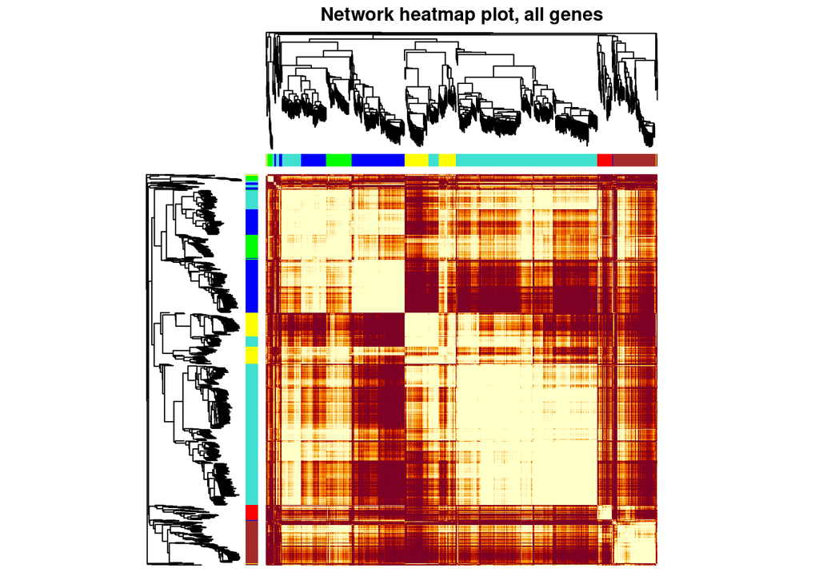

```r
TOMplot(plotTOM, geneTree, moduleColors, main = "Network heatmap plot, all genes")
```

## 5.bVisualizing the network of eigengenes

```r
# Recalculate module eigengenes
MEs = moduleEigengenes(datExpr0, moduleColors)$eigengenes
# Isolate weight from the clinical traits
grup = as.data.frame(as.numeric(datTraits$grup ))
names(grup) = "grup"
# Add the weight to existing module eigengenes

MET = orderMEs(cbind(MEs, grup))
# Plot the relationships among the eigengenes and the trait
sizeGrWindow(5,7.5);
par(cex = 0.9)
```

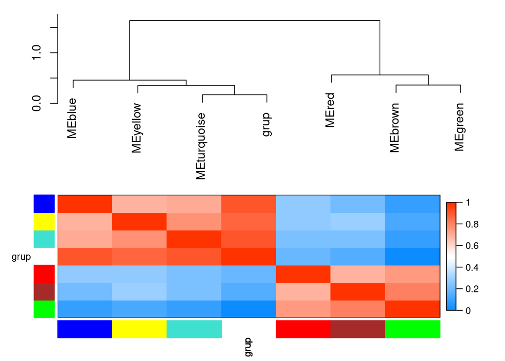

```r
plotEigengeneNetworks(MET, "", marDendro = c(0,4,1,2), marHeatmap = c(3,4,1,2), cex.lab = 0.8, xLabelsAngle
= 90)
```

The function produces a dendrogram of the eigengenes and trait(s), and a heatmap of their relationships. To split the dendrogram and heatmap plots, we can use the following code

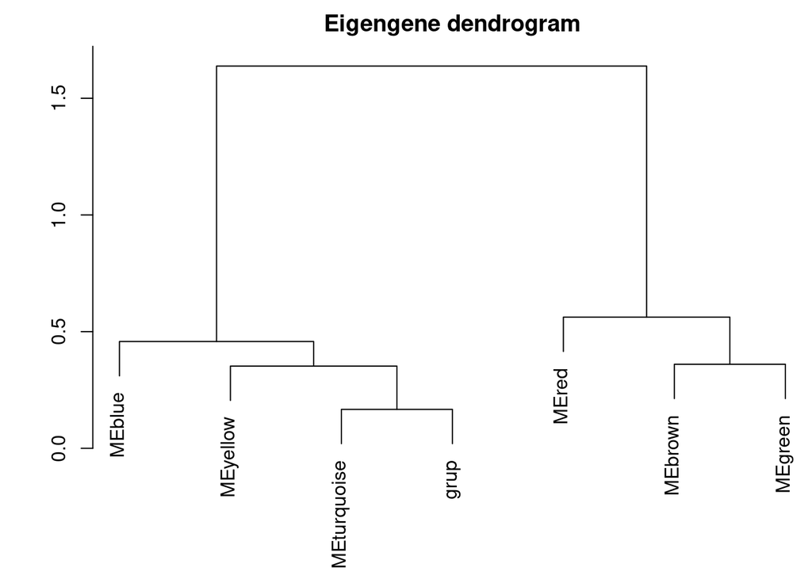

```r
# Plot the dendrogram

par(cex = 1.0)
plotEigengeneNetworks(MET, "Eigengene dendrogram", marDendro = c(0,4,2,0),
plotHeatmaps = FALSE)
```

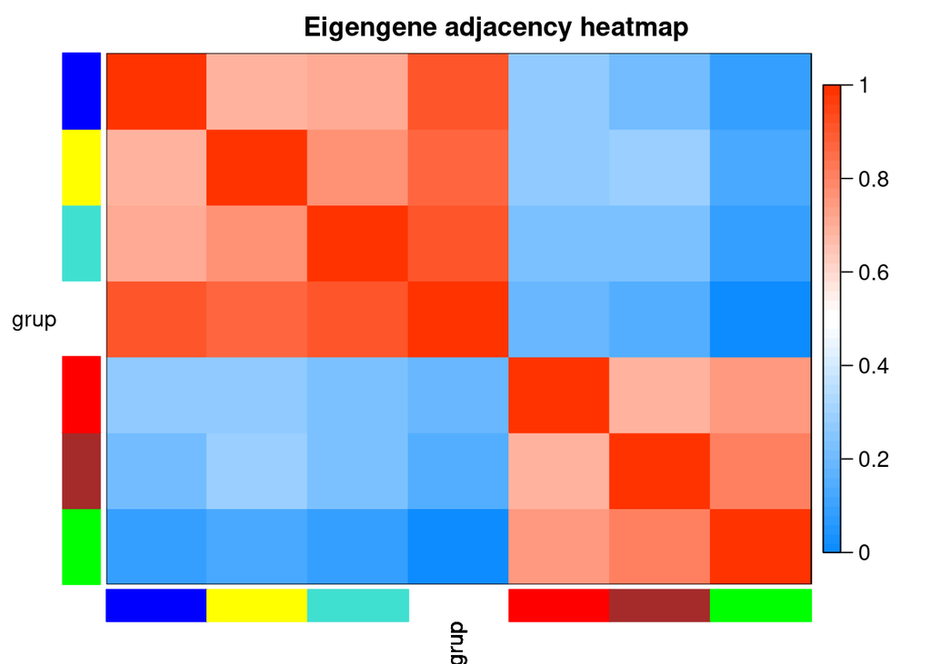

```r
# Plot the heatmap matrix (note: this plot will overwrite the dendrogram plot)
par(cex = 1.0)
plotEigengeneNetworks(MET, "Eigengene adjacency heatmap", marHeatmap = c(3,4,2,2),
plotDendrograms = FALSE, xLabelsAngle = 90)
```

# 6 Exporting to Cytoscape

```r
TOM <-1-dissTOM

modules = moduls_int

probes = colnames(datExpr0)
inModule = is.finite(match(moduleColors, modules));

modProbes = probes[inModule];
# modGenes = annot$gene_symbol[match(modProbes, annot$substanceBXH)];
# Select the corresponding Topological Overlap
modTOM = TOM[inModule, inModule];
dimnames(modTOM) = list(modProbes, modProbes)

dimnames(modTOM) = list(modProbes, modProbes)
# Export the network into edge and node list files Cytoscape can read
cyt = exportNetworkToCytoscape(modTOM,
edgeFile = paste("CytoscapeInput-edges-", paste(modules, collapse="-"), ".txt", sep=""),
nodeFile = paste("CytoscapeInput-nodes-", paste(modules, collapse="-"), ".txt", sep=""),
weighted = TRUE,
threshold = 0.02,
nodeNames = modProbes,
# altNodeNames = modGenes,
nodeAttr = moduleColors[inModule])
```

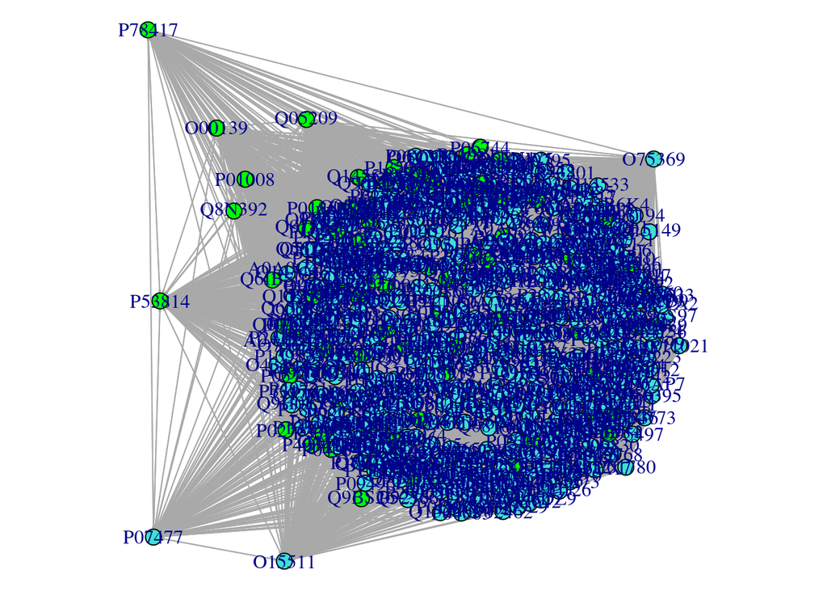

```r
library(igraph)
adj <- modTOM
adj[adj > 0.02] = 1
adj[adj != 1] = 0
network <- graph.adjacency(adj)
network <- simplify(network)  # removes self-loops
results <- net


V(network)$color <- moduleColors[inModule]
V(network)$size<-6
par(mar=c(0,0,0,0))
# remove unconnected nodes
network <- delete.vertices(network, degree(network)==0)
igraph::plot.igraph(network,
                    # mark.groups = T,
                    layout=layout.fruchterman.reingold(network),
     edge.arrow.size = 0.1)
```